# Programa de Pós-Graduação em Computação Aplicada (UnB)

## Disciplina: ANÁLISE ESTATÍSTICA DE DADOS E INFORMAÇÕES - Turma 01 - 2023/1

## Professor: João Gabriel de Moraes Souza

## Aluno: Francisco Gonçalves de Araújo Filho

## Matrícula: 231109675

### Prova 1 - Questão 2

A questão 2 irá se basear na aplicação prática de um problema de Ciência de Dados em Machine Learning. Esses problemas são originados de dados reais aplicados em problemas de Negócios. A questão irá abordar a aplicação do problema Hotel Booking. Esse problema trata-se do objetivo de encontrar um modelo que seja capaz de prever se os indivíduos se cancelam ou não suas reservas em uma rede de hoteis. Com esses dados pede-se:

Fonte dos dados: https://www.kaggle.com/datasets/jessemostipak/hotel-booking-demand

### a) Elaborar uma análise descritiva da base de dados, análise gráfica e por tabelas.

#### Leitura de dados e algumas limpezas

```python
import pandas as pd
import matplotlib.pyplot as plt
import seaborn as sns
import numpy as np
from imblearn.over_sampling import SMOTE
from sklearn.model_selection import train_test_split
from sklearn.feature_selection import RFE
from sklearn.linear_model import LogisticRegression
import statsmodels.api as sm
```

```python
# Substitui texto de uma coluna do Dataframe por indice em um
# dicionário
def substituir_valores_por_indice(df, nome_coluna):
    # Montar dicionário dos diferentes valores contidos na coluna
    valores_unicos = df[nome_coluna].unique()
    dicionario_valores = {valor: indice for indice, valor in enumerate(valores_unicos)}

    # Substituir os valores da coluna pelo valor do índice no dicionário
    df[nome_coluna] = df[nome_coluna].map(dicionario_valores)

    return df, dicionario_valores

# filtra colunas que tenham seu equivalente true
def filtrar_colunas_por_booleano(nomes_colunas, booleanos):
    colunas_filtradas = [coluna for coluna, booleano in zip(nomes_colunas, booleanos) if booleano]
    return colunas_filtradas
```

```python
# Leitura dos dados em um Data frame
df = pd.read_csv('hotel_bookings.csv')
df
```

|  | hotel | is_canceled | lead_time | arrival_date_year | arrival_date_month | arrival_date_week_number | arrival_date_day_of_month | stays_in_weekend_nights | stays_in_week_nights | adults | ... | deposit_type | agent | company | days_in_waiting_list | customer_type | adr | required_car_parking_spaces | total_of_special_requests | reservation_status | reservation_status_date |
| --- | --- | --- | --- | --- | --- | --- | --- | --- | --- | --- | --- | --- | --- | --- | --- | --- | --- | --- | --- | --- | --- |
| 0 | Resort Hotel | 0 | 342 | 2015 | July | 27 | 1 | 0 | 0 | 2 | ... | No Deposit | NaN | NaN | 0 | Transient | 0.00 | 0 | 0 | Check-Out | 2015-07-01 |
| 1 | Resort Hotel | 0 | 737 | 2015 | July | 27 | 1 | 0 | 0 | 2 | ... | No Deposit | NaN | NaN | 0 | Transient | 0.00 | 0 | 0 | Check-Out | 2015-07-01 |
| 2 | Resort Hotel | 0 | 7 | 2015 | July | 27 | 1 | 0 | 1 | 1 | ... | No Deposit | NaN | NaN | 0 | Transient | 75.00 | 0 | 0 | Check-Out | 2015-07-02 |
| 3 | Resort Hotel | 0 | 13 | 2015 | July | 27 | 1 | 0 | 1 | 1 | ... | No Deposit | 304.0 | NaN | 0 | Transient | 75.00 | 0 | 0 | Check-Out | 2015-07-02 |
| 4 | Resort Hotel | 0 | 14 | 2015 | July | 27 | 1 | 0 | 2 | 2 | ... | No Deposit | 240.0 | NaN | 0 | Transient | 98.00 | 0 | 1 | Check-Out | 2015-07-03 |
| ... | ... | ... | ... | ... | ... | ... | ... | ... | ... | ... | ... | ... | ... | ... | ... | ... | ... | ... | ... | ... | ... |
| 119385 | City Hotel | 0 | 23 | 2017 | August | 35 | 30 | 2 | 5 | 2 | ... | No Deposit | 394.0 | NaN | 0 | Transient | 96.14 | 0 | 0 | Check-Out | 2017-09-06 |
| 119386 | City Hotel | 0 | 102 | 2017 | August | 35 | 31 | 2 | 5 | 3 | ... | No Deposit | 9.0 | NaN | 0 | Transient | 225.43 | 0 | 2 | Check-Out | 2017-09-07 |
| 119387 | City Hotel | 0 | 34 | 2017 | August | 35 | 31 | 2 | 5 | 2 | ... | No Deposit | 9.0 | NaN | 0 | Transient | 157.71 | 0 | 4 | Check-Out | 2017-09-07 |
| 119388 | City Hotel | 0 | 109 | 2017 | August | 35 | 31 | 2 | 5 | 2 | ... | No Deposit | 89.0 | NaN | 0 | Transient | 104.40 | 0 | 0 | Check-Out | 2017-09-07 |
| 119389 | City Hotel | 0 | 205 | 2017 | August | 35 | 29 | 2 | 7 | 2 | ... | No Deposit | 9.0 | NaN | 0 | Transient | 151.20 | 0 | 2 | Check-Out | 2017-09-07 |

119390 rows × 32 columns

```python
# Lista toda as colunas com campos nulo
print(df.columns[df.isnull().any()])
```

```
Index(['children', 'country', 'agent', 'company'], dtype='object')
```

```python
# Pressupostos:
# Criança: assume-se que não haja quando valor é nulo
# País: assume-se que 'desconhecido' quando valor é nulo
# Criança: assume-se que não haja crianção quando valor é nulo
# Agente: assume-se que não haja quando valor é nulo
# Agencia: assume-se que não criança quando valor é nulo
troca_nan = {"children": 0,"country": "Unknown", "agent": 0, "company": 0}
df = df.fillna(troca_nan)
```

```python
# Lista toda as colunas com campos nulo
print(df.columns[df.isnull().any()])
```

```
Index([], dtype='object')
```

```python
# "meal" conforme dicionário "Undefined" é o mesmo que 'SC'.
df["meal"].replace("Undefined", "SC", inplace=True)

# Algumas linhas contém ao mesmo tempo 0 adults, 0 children and 0 babies.
# Dropando linhas com 0 hópedes.
zero_guests = list(df.loc[df["adults"]
                   + df["children"]
                   + df["babies"]==0].index)
df.drop(df.index[zero_guests], inplace=True)
```

```python
# Distribuição de cancelados e não cancelados
df['is_canceled'].value_counts()
```

```
is_canceled
0    75011
1    44199
Name: count, dtype: int64
```

```python
# Quanto dado sobrou? Quantas colunas?
df.shape
```

```
(119210, 32)
```

O principal interesse no problema é compreender como as variáveis condicionais fornecidas se relacionam com o status da variável de interesse *'is_canceled'*, relativa ao cancelamento ou não da reserva.

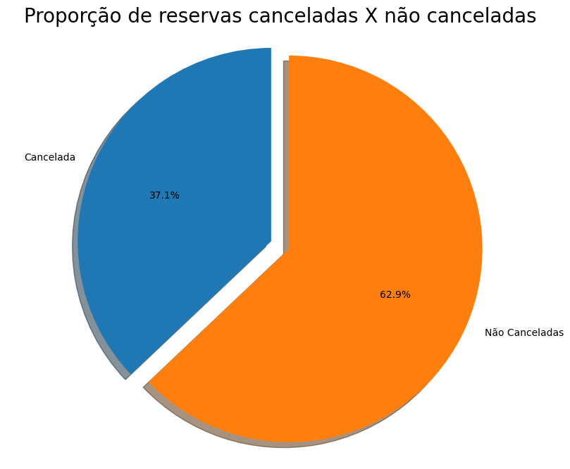

```python
labels = 'Cancelada', 'Não Canceladas'
sizes = [df.is_canceled[df['is_canceled']==1].count(), df.is_canceled[df['is_canceled']==0].count()]
explode = (0, 0.1)
fig1, ax1 = plt.subplots(figsize=(10, 8))
ax1.pie(sizes, explode=explode, labels=labels, autopct='%1.1f%%',
        shadow=True, startangle=90)
ax1.axis('equal')
plt.title("Proporção de reservas canceladas X não canceladas", size = 20)
plt.show()
```

#### Investiga as variáveis categóricas em relação à variavel de interesse

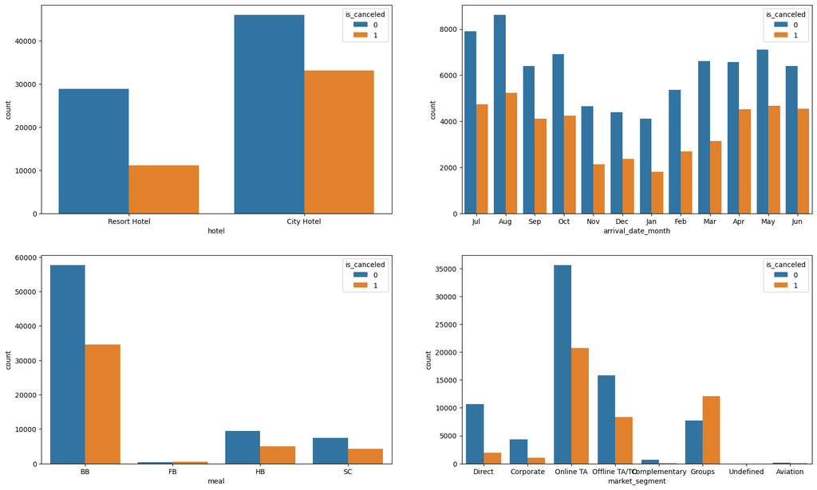

```python
# Variáveis categóricas
fig, axarr = plt.subplots(2, 2, figsize=(20, 12))
sns.countplot(x='hotel', hue='is_canceled', data=df, ax=axarr[0][0])
ax = sns.countplot(x='arrival_date_month', hue='is_canceled', data=df, ax=axarr[0][1])
ax.set_xticklabels([item.get_text()[:3] for item in ax.get_xticklabels()])
sns.countplot(x='meal', hue='is_canceled', data=df, ax=axarr[1][0])
sns.countplot(x='market_segment', hue='is_canceled', data=df, ax=axarr[1][1])

plt.show()
```

#### Análise dos gráficos

Os dados representam apenas as reservas realizadas em dois hotéis, um resort eu um hotel na cidade. Percebe-se no gráfico de contagem de reservas por tipo de hotel que a preferência é pelo hotel na cidade, mas ao analisar a variável de interesse, o cancelamento no resort, proporcionalmente é inferior aos cancelamentos no hotel da cidade.

Quanto a contagem de reservas nos meses do ano, vê-se claramente que o número de reservas durante o inverno europeu é menor em relação as outras épocas do ano, no entanto, o relação entre reservas canceladas e não canceladas parece se manter.

Quanto a categoria de refeições reservadas, a mais frequente é da categoria BB. Mais uma vez, a relação entre reservas canceladas e não canceladas parece se manter, com relação à categoria escolhida.

O Seguimento de Market que agenciou a viagem tem um destaque na preferência de agendamento em agentes de viagem online. Outro destaque significativo é que reservas feitas em grupo tem um nível de cancelamento maior que as reservas confirmadas.

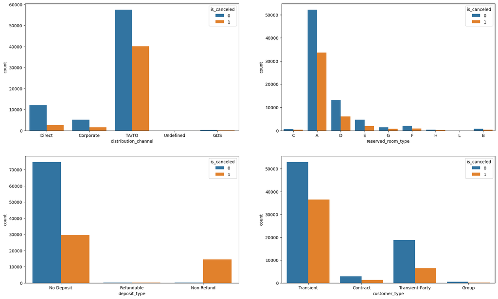

```python
# Mais variáveis categóricas
fig, axarr = plt.subplots(2, 2, figsize=(20, 12))
sns.countplot(x='distribution_channel', hue='is_canceled', data=df, ax=axarr[0][0])
sns.countplot(x='reserved_room_type', hue='is_canceled', data=df, ax=axarr[0][1])
sns.countplot(x='deposit_type', hue='is_canceled', data=df, ax=axarr[1][0])
sns.countplot(x='customer_type', hue='is_canceled', data=df, ax=axarr[1][1])

plt.show()
```

#### Análise dos gráficos

Dos gráficos apresentados, o destaque é a variável “tipo de deposito” para reserva, onde a contagem de cancelamento para depósitos sem devolução é muito alto. O Tipo de quarto preferido é o “A”. O Canal principal para distribuição das reservas é o seguimento Agência/Agente de viagem.

#### Investiga as variáveis contínuas em relação à variavel de interesse

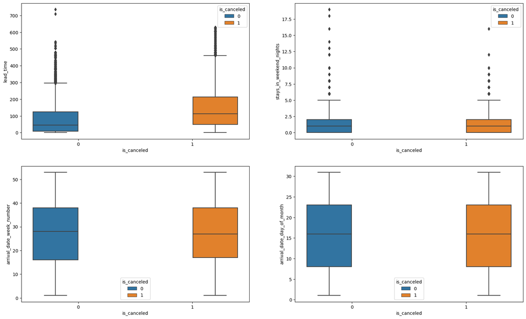

```python
# Revisão da relação entre a variável de interesse e as variáveis contínuas.
fig, axarr = plt.subplots(2, 2, figsize=(20, 12))
sns.boxplot(y='lead_time',x = 'is_canceled', hue = 'is_canceled',data = df, ax=axarr[0][0])
sns.boxplot(y='stays_in_weekend_nights',x = 'is_canceled', hue = 'is_canceled',data = df , ax=axarr[0][1])
sns.boxplot(y='arrival_date_week_number',x = 'is_canceled', hue = 'is_canceled',data = df, ax=axarr[1][0])
sns.boxplot(y='arrival_date_day_of_month',x = 'is_canceled', hue = 'is_canceled',data = df, ax=axarr[1][1])
```

### b) Realize a previsão por um modelo de Regressão Logística

#### As seguintes operação são feitas a seguir:

- **Organização a ordem das colunas por tipo de dados**:
  1. Variável de interesse;
  2. Variáveis contínuas;
  3. Variáveis categóricas (discretas).
- **Aplicação do formato *on-hot* e *codificação simétrica*** para as demais variáveis categóricas.

```python
# Organizando as colunas
cont_features = ["lead_time","arrival_date_week_number","arrival_date_day_of_month",
                "stays_in_weekend_nights","stays_in_week_nights","adults","children",
                "babies", "previous_cancellations",
                "previous_bookings_not_canceled","agent","company",
                "total_of_special_requests", "adr",
                "country", "days_in_waiting_list"]

cate_features = ["hotel","arrival_date_month","meal","market_segment",
                "distribution_channel","reserved_room_type","deposit_type","customer_type",
                "is_repeated_guest"]


df = df[['is_canceled'] + cont_features + cate_features]
df.head()
```

|  | is_canceled | lead_time | arrival_date_week_number | arrival_date_day_of_month | stays_in_weekend_nights | stays_in_week_nights | adults | children | babies | previous_cancellations | ... | days_in_waiting_list | hotel | arrival_date_month | meal | market_segment | distribution_channel | reserved_room_type | deposit_type | customer_type | is_repeated_guest |
| --- | --- | --- | --- | --- | --- | --- | --- | --- | --- | --- | --- | --- | --- | --- | --- | --- | --- | --- | --- | --- | --- |
| 0 | 0 | 342 | 27 | 1 | 0 | 0 | 2 | 0.0 | 0 | 0 | ... | 0 | Resort Hotel | July | BB | Direct | Direct | C | No Deposit | Transient | 0 |
| 1 | 0 | 737 | 27 | 1 | 0 | 0 | 2 | 0.0 | 0 | 0 | ... | 0 | Resort Hotel | July | BB | Direct | Direct | C | No Deposit | Transient | 0 |
| 2 | 0 | 7 | 27 | 1 | 0 | 1 | 1 | 0.0 | 0 | 0 | ... | 0 | Resort Hotel | July | BB | Direct | Direct | A | No Deposit | Transient | 0 |
| 3 | 0 | 13 | 27 | 1 | 0 | 1 | 1 | 0.0 | 0 | 0 | ... | 0 | Resort Hotel | July | BB | Corporate | Corporate | A | No Deposit | Transient | 0 |
| 4 | 0 | 14 | 27 | 1 | 0 | 2 | 2 | 0.0 | 0 | 0 | ... | 0 | Resort Hotel | July | BB | Online TA | TA/TO | A | No Deposit | Transient | 0 |

5 rows × 26 columns

```python
# usando formato "one-hot" para as demais variáveis categóricas
lst = cate_features
remove = list()
for i in lst:
    if (df[i].dtype == str or df[i].dtype == object):
        for j in df[i].unique():
            df[i+'_'+j] = np.where(df[i] == j,1,0)
        remove.append(i)
df = df.drop(remove, axis=1)
print(df.columns)
print(len(df.columns))
```

```
Index(['is_canceled', 'lead_time', 'arrival_date_week_number',
       'arrival_date_day_of_month', 'stays_in_weekend_nights',
       'stays_in_week_nights', 'adults', 'children', 'babies',
       'previous_cancellations', 'previous_bookings_not_canceled', 'agent',
       'company', 'total_of_special_requests', 'adr', 'country',
       'days_in_waiting_list', 'is_repeated_guest', 'hotel_Resort Hotel',
       'hotel_City Hotel', 'arrival_date_month_July',
       'arrival_date_month_August', 'arrival_date_month_September',
       'arrival_date_month_October', 'arrival_date_month_November',
       'arrival_date_month_December', 'arrival_date_month_January',
       'arrival_date_month_February', 'arrival_date_month_March',
       'arrival_date_month_April', 'arrival_date_month_May',
       'arrival_date_month_June', 'meal_BB', 'meal_FB', 'meal_HB', 'meal_SC',
       'market_segment_Direct', 'market_segment_Corporate',
       'market_segment_Online TA', 'market_segment_Offline TA/TO',
       'market_segment_Complementary', 'market_segment_Groups',
       'market_segment_Undefined', 'market_segment_Aviation',
       'distribution_channel_Direct', 'distribution_channel_Corporate',
       'distribution_channel_TA/TO', 'distribution_channel_Undefined',
       'distribution_channel_GDS', 'reserved_room_type_C',
       'reserved_room_type_A', 'reserved_room_type_D', 'reserved_room_type_E',
       'reserved_room_type_G', 'reserved_room_type_F', 'reserved_room_type_H',
       'reserved_room_type_L', 'reserved_room_type_B',
       'deposit_type_No Deposit', 'deposit_type_Refundable',
       'deposit_type_Non Refund', 'customer_type_Transient',
       'customer_type_Contract', 'customer_type_Transient-Party',
       'customer_type_Group'],
      dtype='object')
65
```

```python
# Encode para País
tipos_string = df[cont_features].select_dtypes(include='object').dtypes
print(tipos_string)
df, dicionario_country  = substituir_valores_por_indice(df, 'country')
tipos_string = df[cont_features].select_dtypes(include='object').dtypes
print(tipos_string)
print(dicionario_country)
```

[output not shown]

#### Rebalanceando o banco de dados

Nesse passo aplicaremos o algorítmo SMOTE (Synthetic Minority Oversampling Technique) de balanceamento das amostras de treinamento.

O algoritmo SMOTE (Synthetic Minority Over-sampling Technique) é uma técnica de balanceamento de classes utilizada em problemas de aprendizado de máquina quando há desequilíbrio entre as classes do conjunto de dados. O desequilíbrio de classes ocorre quando uma classe tem um número significativamente menor de exemplos em relação a outras classes.

```python
col_y = 'is_canceled'
X = df.loc[:, df.columns != col_y]
y = df.loc[:, df.columns == col_y]
os = SMOTE(random_state=0)
X_train, X_test, y_train, y_test = train_test_split(X, y, test_size=0.3, random_state=0)
columns = X_train.columns
os_data_X,os_data_y=os.fit_resample(X_train, y_train)
os_data_X = pd.DataFrame(data=os_data_X,columns=columns )
os_data_y= pd.DataFrame(data=os_data_y,columns=[col_y])
# Checando as quantidades
print("Tamanho do oversampled é: ",len(os_data_X))
print("Número de não aderência:",len(os_data_y[os_data_y[col_y]==0]))
print("Número de aderência:",len(os_data_y[os_data_y[col_y]==1]))
print("Proporção de não aderência: ",len(os_data_y[os_data_y[col_y]==0])/len(os_data_X)*100, "%")
print("Proporção de aderência:", len(os_data_y[os_data_y[col_y]==1])/len(os_data_X)*100, "%")
```

```
Tamanho do oversampled é:  105254
Número de não aderência: 52627
Número de aderência: 52627
Proporção de não aderência:  50.0 %
Proporção de aderência: 50.0 %
```

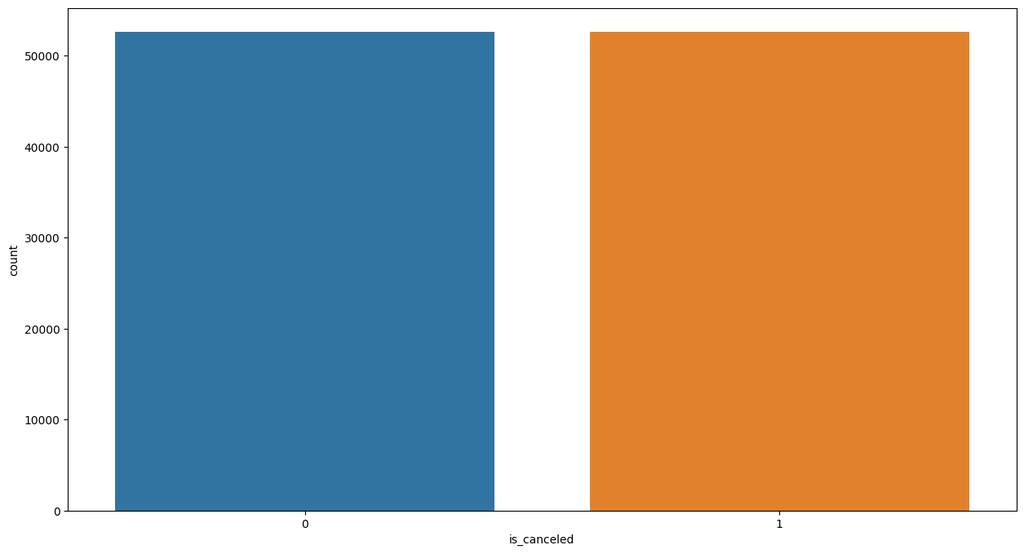

```python
plt.figure(figsize=(15,8))
figure = sns.countplot(x=col_y, data = os_data_y)
```

```python
# Separa cojunto de amostra de treinamento
X=os_data_X.loc[:, os_data_X.columns != col_y]
y=os_data_y[col_y]
# Separa cojunto de amostra de teste
y_t = y_test[col_y]
X_t = X_test.loc[:, X_test.columns != col_y]
```

#### Seleção de Variáveis via LOGIT

Recursive Feature Elimination (RFE) é baseada na ideia de repetidamente construir um modelo e selecionar as variáveis que apresentam as melhores e as piores performance. O processo é repetido recursivamente até que sejam selecionadas as variáveis que mais importam para o modelo, de modo a ficar com um número parcimonioso de variáveis.

```python
rfe = RFE(estimator=LogisticRegression(), n_features_to_select=30)
rfe = rfe.fit(X, y)

print(rfe.support_)
print(rfe.ranking_)
```

[output not shown]

[output cut: 217 more lines]

[output not shown]

```
[False False False False False False False False False False False False
 False False False False False False False  True  True  True  True  True
  True  True  True  True  True  True  True  True  True  True  True False
 False False False False False False False  True False False False False
  True  True  True  True  True  True  True False  True False False  True
  True  True  True  True]
[25 30 35 27 22 15 18 21  5 13 29 33 10 24 23 28  6 19 14  1  1  1  1  1
  1  1  1  1  1  1  1  1  1  1  1 17  8 11  9 26 20 32 12  1  3  4 31  2
  1  1  1  1  1  1  1 34  1  7 16  1  1  1  1  1]
```

```python
# Filtra colunas de features mais significativas
cols = filtrar_colunas_por_booleano(os_data_X.columns.values, rfe.support_)
print(cols)
print(len(cols))
```

[output not shown]

```python
df_temp = os_data_X[cols]
# Reatribuindo X e y com colunas restantes
X=os_data_X[cols]
y=os_data_y[col_y]
```

#### Implementando o LOGIT

```python
logit_model=sm.Logit(y,X)
result=logit_model.fit()
print(result.summary2())
```

```
Optimization terminated successfully.
         Current function value: 0.509206
         Iterations 10
                                Results: Logit
==============================================================================
Model:                  Logit                Method:               MLE
Dependent Variable:     is_canceled          Pseudo R-squared:     0.265
Date:                   2023-07-03 12:47     AIC:                  107251.9961
No. Observations:       105254               BIC:                  107538.9201
Df Model:               29                   Log-Likelihood:       -53596.
Df Residuals:           105224               LL-Null:              -72957.
Converged:              1.0000               LLR p-value:          0.0000
No. Iterations:         10.0000              Scale:                1.0000
------------------------------------------------------------------------------
                               Coef.  Std.Err.    z     P>|z|   [0.025  0.975]
------------------------------------------------------------------------------
arrival_date_month_July       -2.1085   0.0535 -39.3989 0.0000 -2.2134 -2.0036
arrival_date_month_August     -2.0716   0.0529 -39.1581 0.0000 -2.1752 -1.9679
arrival_date_month_September  -2.4392   0.0563 -43.3309 0.0000 -2.5495 -2.3288
arrival_date_month_October    -2.3761   0.0555 -42.8387 0.0000 -2.4848 -2.2674
arrival_date_month_November   -2.6992   0.0594 -45.4339 0.0000 -2.8157 -2.5828
arrival_date_month_December   -2.3814   0.0581 -40.9576 0.0000 -2.4954 -2.2675
arrival_date_month_January    -2.7326   0.0609 -44.8454 0.0000 -2.8520 -2.6131
arrival_date_month_February   -2.4638   0.0572 -43.1011 0.0000 -2.5758 -2.3517
arrival_date_month_March      -2.6195   0.0561 -46.7127 0.0000 -2.7294 -2.5096
arrival_date_month_April      -2.3244   0.0549 -42.3413 0.0000 -2.4320 -2.2168
arrival_date_month_May        -2.2982   0.0545 -42.1879 0.0000 -2.4050 -2.1915
arrival_date_month_June       -2.3572   0.0551 -42.8039 0.0000 -2.4651 -2.2492
meal_BB                       -0.1686   0.0478  -3.5273 0.0004 -0.2622 -0.0749
meal_FB                        0.3981   0.1129   3.5250 0.0004  0.1767  0.6194
meal_HB                       -0.3665   0.0530  -6.9204 0.0000 -0.4703 -0.2627
meal_SC                       -0.0396   0.0525  -0.7533 0.4513 -0.1425  0.0634
distribution_channel_Direct   -1.0916   0.0275 -39.7154 0.0000 -1.1455 -1.0377
reserved_room_type_C          -0.9199   0.0977  -9.4143 0.0000 -1.1115 -0.7284
reserved_room_type_A          -0.8837   0.0448 -19.7068 0.0000 -0.9716 -0.7958
reserved_room_type_D          -0.9258   0.0477 -19.4281 0.0000 -1.0192 -0.8324
reserved_room_type_E          -1.0086   0.0549 -18.3558 0.0000 -1.1162 -0.9009
reserved_room_type_G          -0.6991   0.0700  -9.9868 0.0000 -0.8363 -0.5619
reserved_room_type_F          -0.8858   0.0648 -13.6591 0.0000 -1.0129 -0.7587
reserved_room_type_H          -0.6918   0.1123  -6.1582 0.0000 -0.9120 -0.4716
reserved_room_type_B          -0.6758   0.0871  -7.7547 0.0000 -0.8466 -0.5050
deposit_type_Non Refund        6.2487   0.1320  47.3212 0.0000  5.9899  6.5075
customer_type_Transient        3.0289   0.0595  50.9264 0.0000  2.9123  3.1454
customer_type_Contract         2.3268   0.0750  31.0168 0.0000  2.1798  2.4738
customer_type_Transient-Party  2.6926   0.0631  42.7034 0.0000  2.5690  2.8161
customer_type_Group            1.5777   0.1662   9.4942 0.0000  1.2520  1.9034
==============================================================================
```

#### Analisado reusltado do Modelo de Regressão Logística ajustado

- **Modelo**: O tipo de modelo ajustado é um modelo de regressão logística.
- **Método**: O método utilizado para ajustar o modelo foi o MLE (Estimação de Máxima Verossimilhança).
- **Variável Dependente**: A variável dependente do modelo é chamada de "is_canceled".
- **Pseudo R-quadrado**: O valor do pseudo R-quadrado (0.265) indica o ajuste do modelo aos dados. Quanto mais próximo de 1, melhor o ajuste.
- **Observações**: O número de observações utilizadas no ajuste do modelo é 105.254.
- **AIC e BIC**: Essas são métricas utilizadas para comparar diferentes modelos. Valores mais baixos indicam um ajuste melhor. Coeficientes: Os coeficientes estimados para cada uma das variáveis independentes incluídas no modelo. Cada coeficiente é acompanhado do seu erro padrão, estatísticas de teste z, valores de p e intervalo de confiança de 95%.
- **Convergência**: A informação de "Converged" indica se o algoritmo de ajuste convergiu para uma solução. Neste caso, o valor é 1, o que significa que a convergência ocorreu. Iterações: O número de iterações necessárias para que o algoritmo de ajuste convergisse.

### c) Encontre as features mais importantes para o cancelamento das reservas, interprete os resultados.

```python
log_odds = result.params.values
pd.DataFrame(log_odds,
             X.columns,
             columns=['coef'])\
            .sort_values(by='coef', ascending=False)
```

|  | coef |
| --- | --- |
| deposit_type_Non Refund | 6.248660 |
| customer_type_Transient | 3.028871 |
| customer_type_Transient-Party | 2.692551 |
| customer_type_Contract | 2.326797 |
| customer_type_Group | 1.577689 |
| meal_FB | 0.398089 |
| meal_SC | -0.039553 |
| meal_BB | -0.168575 |
| meal_HB | -0.366488 |
| reserved_room_type_B | -0.675791 |
| reserved_room_type_H | -0.691808 |
| reserved_room_type_G | -0.699068 |
| reserved_room_type_A | -0.883701 |
| reserved_room_type_F | -0.885768 |
| reserved_room_type_C | -0.919950 |
| reserved_room_type_D | -0.925846 |
| reserved_room_type_E | -1.008552 |
| distribution_channel_Direct | -1.091582 |
| arrival_date_month_August | -2.071558 |
| arrival_date_month_July | -2.108536 |
| arrival_date_month_May | -2.298239 |
| arrival_date_month_April | -2.324428 |
| arrival_date_month_June | -2.357161 |
| arrival_date_month_October | -2.376090 |
| arrival_date_month_December | -2.381411 |
| arrival_date_month_September | -2.439151 |
| arrival_date_month_February | -2.463770 |
| arrival_date_month_March | -2.619480 |
| arrival_date_month_November | -2.699221 |
| arrival_date_month_January | -2.732573 |

```python
odds = np.exp(result.params.values)
pd.DataFrame(odds,
             X.columns,
             columns=['coef'])\
            .sort_values(by='coef', ascending=False)
```

|  | coef |
| --- | --- |
| deposit_type_Non Refund | 517.319143 |
| customer_type_Transient | 20.673880 |
| customer_type_Transient-Party | 14.769300 |
| customer_type_Contract | 10.245071 |
| customer_type_Group | 4.843748 |
| meal_FB | 1.488976 |
| meal_SC | 0.961219 |
| meal_BB | 0.844868 |
| meal_HB | 0.693164 |
| reserved_room_type_B | 0.508754 |
| reserved_room_type_H | 0.500670 |
| reserved_room_type_G | 0.497048 |
| reserved_room_type_A | 0.413251 |
| reserved_room_type_F | 0.412397 |
| reserved_room_type_C | 0.398539 |
| reserved_room_type_D | 0.396196 |
| reserved_room_type_E | 0.364747 |
| distribution_channel_Direct | 0.335685 |
| arrival_date_month_August | 0.125989 |
| arrival_date_month_July | 0.121416 |
| arrival_date_month_May | 0.100436 |
| arrival_date_month_April | 0.097839 |
| arrival_date_month_June | 0.094689 |
| arrival_date_month_October | 0.092913 |
| arrival_date_month_December | 0.092420 |
| arrival_date_month_September | 0.087235 |
| arrival_date_month_February | 0.085113 |
| arrival_date_month_March | 0.072841 |
| arrival_date_month_November | 0.067258 |
| arrival_date_month_January | 0.065052 |

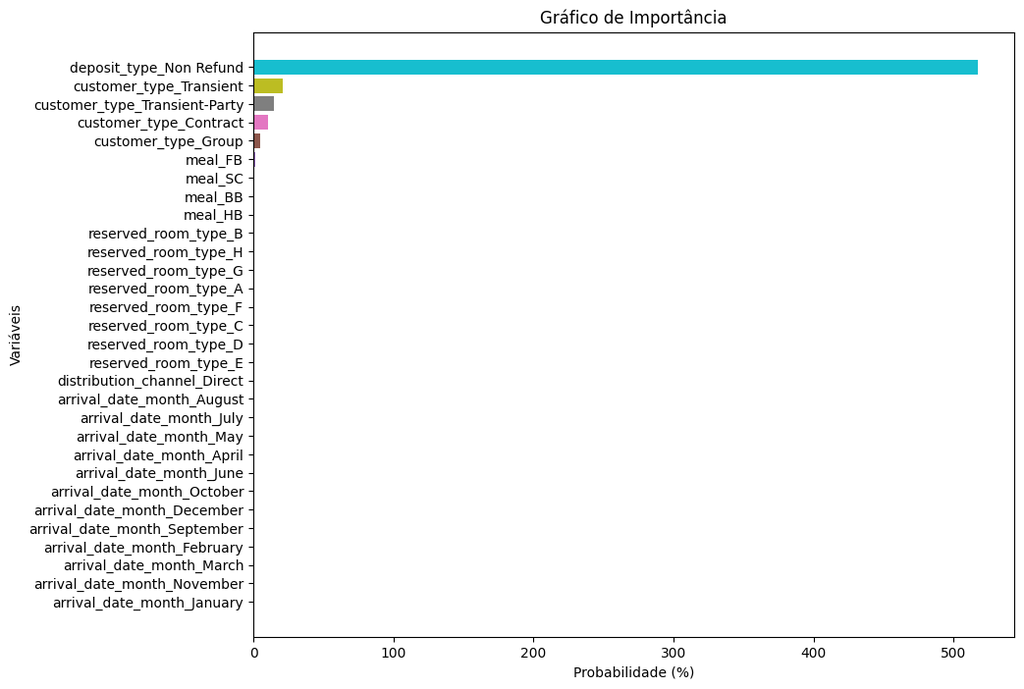

```python
coefficients = pd.DataFrame(odds, X.columns, columns=['coef']).sort_values(by='coef', ascending=True)

plt.figure(figsize=(10,8))
plt.barh(coefficients.index, coefficients['coef'], color=['C{}'.format(i) for i in range(len(coefficients))])
plt.xlabel('Probabilidade (%)')
plt.ylabel('Variáveis')
plt.title('Gráfico de Importância')
plt.show()
```

#### Acima estão listadas as features mais importantes para o cancelamento das reservas

```python
logreg = LogisticRegression()
logreg.fit(X_t, y_t)
```

```
LogisticRegression()
```

#### Ajustantod o modelo de regressão logistica

```python
y_pred = logreg.predict(X_t)
print('Acurácia do Modelo na Base de Teste: {:.2f}'.format(logreg.score(X_test, y_test)))
```

```
Acurácia do Modelo na Base de Teste: 0.78
```

#### Acurácia

A acurácia do modelo de regressão logística na base de teste, que é uma medida de desempenho que indica a proporção de previsões corretas em relação ao total de previsões realizadas é de 78%.

```python
from sklearn.metrics import confusion_matrix
confusion_matrix = confusion_matrix(y_test, y_pred)
print(confusion_matrix)
```

```
[[20276  2108]
 [ 5619  7760]]
```

#### Matriz de confusão

Na diagonal principal da matriz, temos os valores corretamente classificados. No caso específico, temos 20.276 exemplos que foram classificados corretamente como pertencentes à classe negativa (verdadeiros negativos) e 7.760 exemplos classificados corretamente como pertencentes à classe positiva (verdadeiros positivos).

Fora da diagonal principal, temos os valores de classificação incorreta. Neste caso, temos 2.108 exemplos que foram erroneamente classificados como pertencentes à classe positiva (falsos positivos) e 5.619 exemplos classificados erroneamente como pertencentes à classe negativa (falsos negativos).

```python
from sklearn.metrics import classification_report
print(classification_report(y_test, y_pred))
```

```
              precision    recall  f1-score   support

           0       0.78      0.91      0.84     22384
           1       0.79      0.58      0.67     13379

    accuracy                           0.78     35763
   macro avg       0.78      0.74      0.75     35763
weighted avg       0.78      0.78      0.78     35763
```

Tabela com métricas de classificação detalhadas:

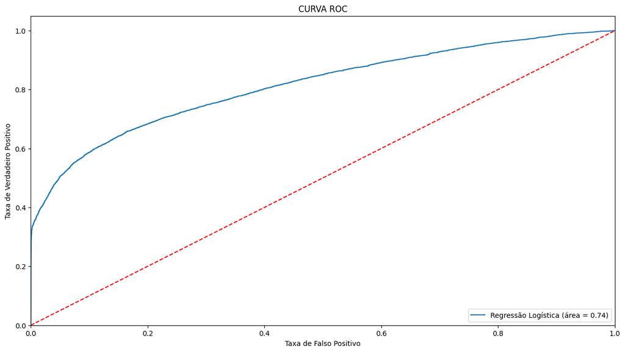

```python
from sklearn.metrics import roc_auc_score
from sklearn.metrics import roc_curve
logit_roc_auc = roc_auc_score(y_t, logreg.predict(X_t))
fpr, tpr, thresholds = roc_curve(y_t, logreg.predict_proba(X_t)[:,1])
plt.figure()
plt.figure(figsize=(15,8))
plt.plot(fpr, tpr, label='Regressão Logística (área = %0.2f)' % logit_roc_auc)
plt.plot([0, 1], [0, 1],'r--')
plt.xlim([0.0, 1.0])
plt.ylim([0.0, 1.05])
plt.xlabel('Taxa de Falso Positivo')
plt.ylabel('Taxa de Verdadeiro Positivo')
plt.title('CURVA ROC')
plt.legend(loc="lower right")
plt.show()
```

### d) Explique o motivo do uso da regressão logística e não de regressão linear

A regressão logística é frequentemente preferida em vez da regressão linear quando a variável de resposta é binária ou categórica, que é exatamento o caso do problema tratado. A regressão linear assume uma variável de resposta contínua, enquanto a regressão logística lida especificamente com uma variável de resposta binária ou categórica.